# Analysis of Flight Delays

## Create by: Alexandre Benson Smith

## Investigation overview

The purpose of this investigation is to find out which characteristics are most related to the delay of a flight. The main point is time related factors, such as month, day of the month, day of the week, day of the week / weekend and time of scheduled arrival.

The delay analysis is based on arrival time delays, specifically A + 15 (arrival at the gate within 15 minutes of scheduled arrival), since this is the measure that the U.S. Department of Transportation (U.S.DOT) reports.

## Dataset overview

The investigation explored the U.S.DOT data set for 2007 flights in the U.S. This data set contains information about the punctual performance of airlines and flight delays. It covers nonstop scheduled service flights between points within the United States operated by 21 airlines.

There are 7,275,259 flights in the data set after cleaning.

## Distribution of Delayed Flights

Only 24.8% of flights were delayed.Most airlines report time-related KPIs to the aviation authorities and airports in order to keep their operations.

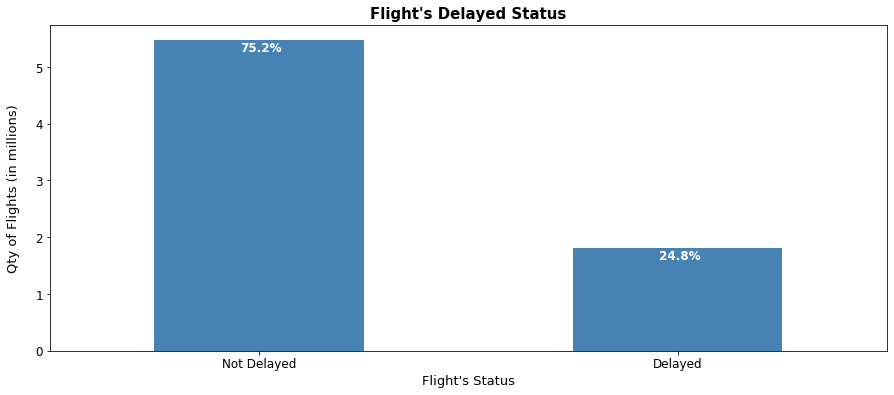

```python
# Distribution of annual delayed flights
barplot_delayed()
```

## Delayed Flights through the months

The amount of delayed flights is always lower than the amount of not delayed flights throughout the months. There a little variance on the data

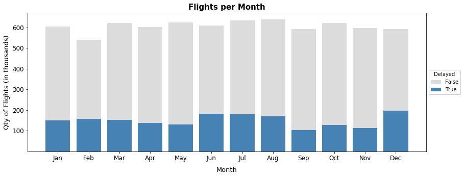

```python
# Amount of delayed and not delayed flights per month
barplot_delayedmonth()
```

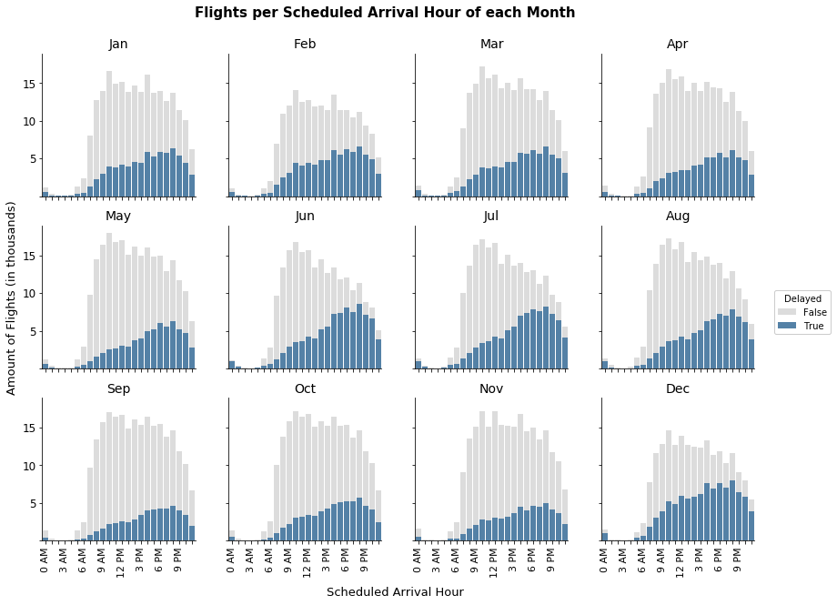

```python
# Aamount of delayed and not delayed flights per scheduled arrival hour of each month
barplot_hourmonth()
```

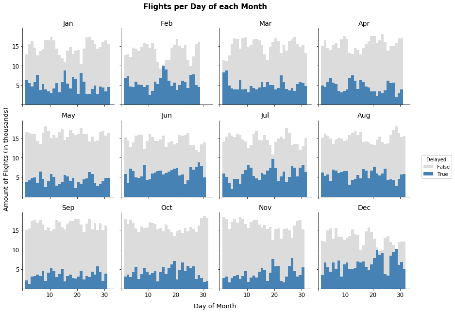

```python
# Amount of delayed and not delayed flights each day of each month
barplot_daymonth()
```

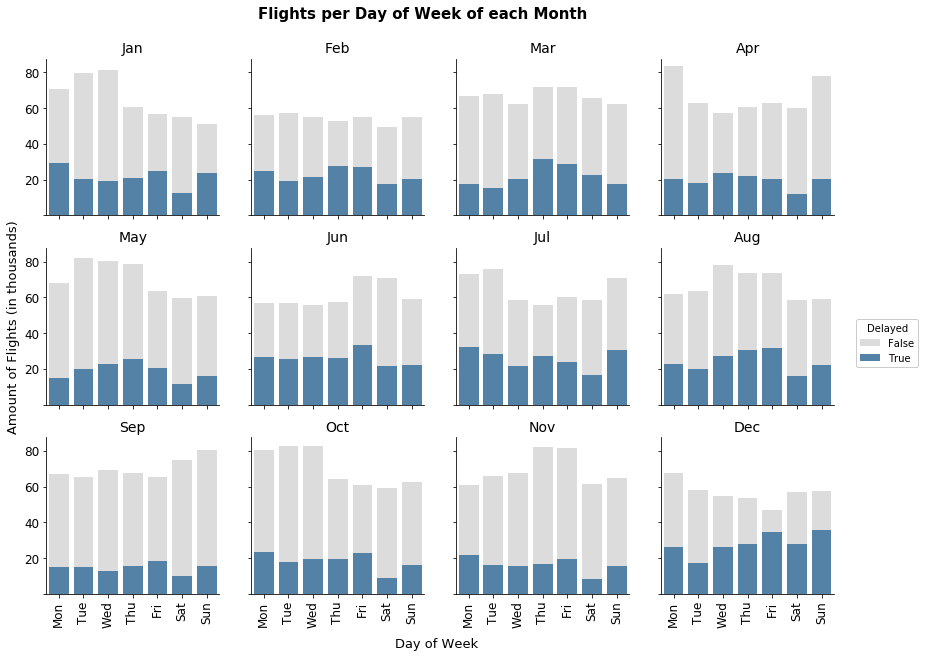

```python
# Amount of delayed and not delayed flights each day of week of   each month
barplot_weekdaymonth()
```

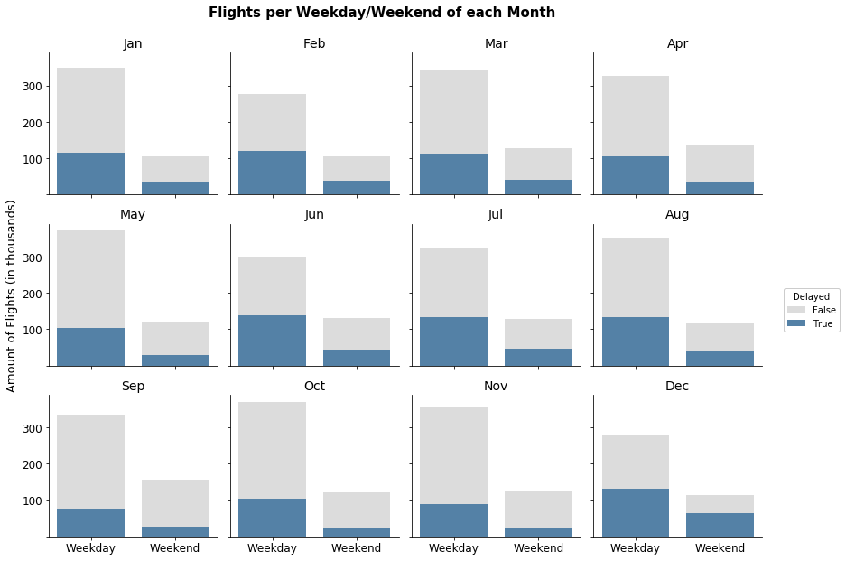

```python
# Amount of delayed and not delayed flights each weekday/weekend  of each month
barplot_weekdayweekend()
```

## Percentage of Delayed Flights per hour

There are more delays per hour between 9 PM and 0 AM, and a reduction in the percent of delays at 7 AM.

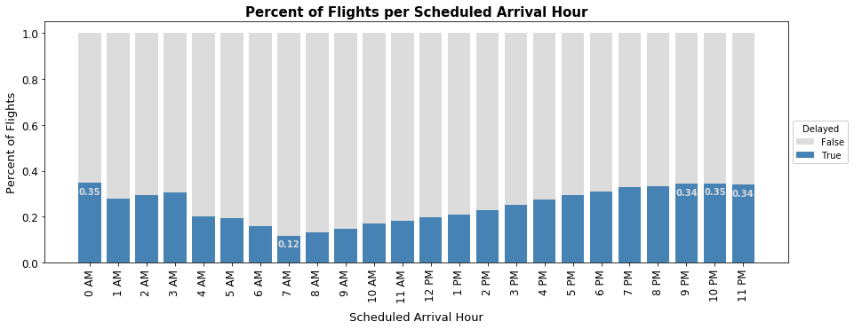

```python
# Percent of Flights per Scheduled Arrival Hour
barplot_scheduledarrivalhour()
```

## Percentage of Delayed Flights per day of week

Saturday has the lowest percent of delayed flights.

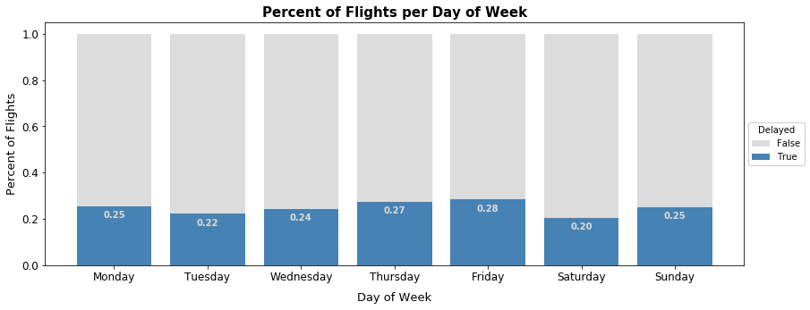

```python
# Annual Percent of Flights per Day of Week
barplot_weekday()
```

## Percentage of Delayed Flights per weekday/weekend

Weekdays and weekends has similar delayed flightspercentage,being it slightly higher on weekdays.

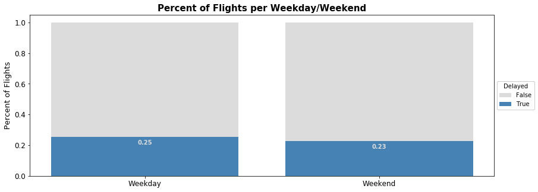

```python
# Annual Percent of Flights per Weekday/Weekend
barplot_prcent_weekdayweekend()
```